# Data 624 - Homework #5

## Question 8.6

Use R to simulate and plot some data from simple ARIMA models.

### A) Use the following R code to generate data from an AR(1) model with $\phi_1 = 0.6$ and $\sigma^2 = 1$ The process starts with $y1 = 0$

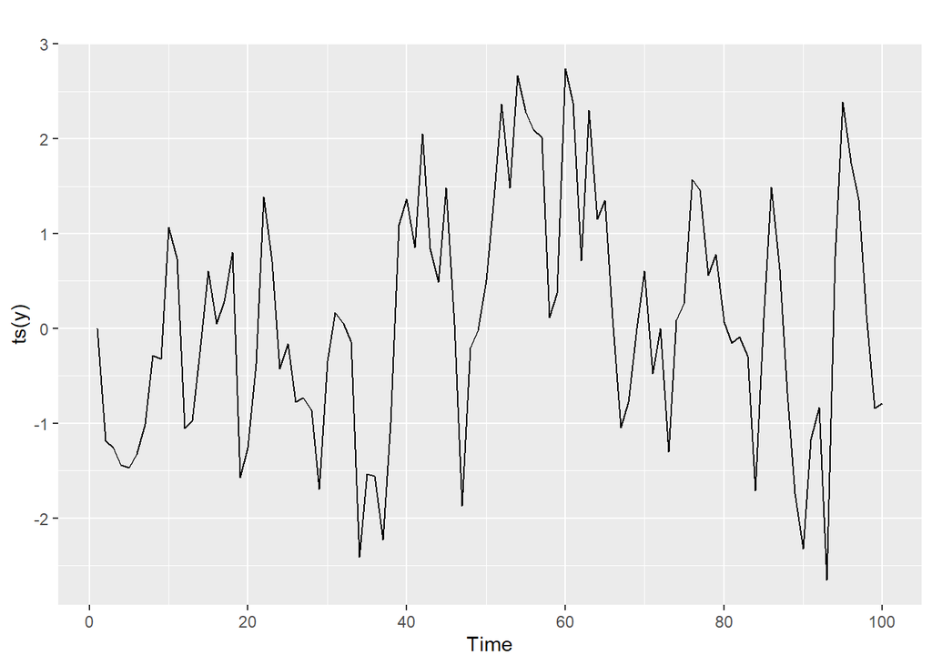

```r
#from the problem
y <- ts(numeric(100))
e <- rnorm(100)
for(i in 2:100){
   y[i] <- 0.6*y[i-1] + e[i]
}

autoplot(ts(y))
```

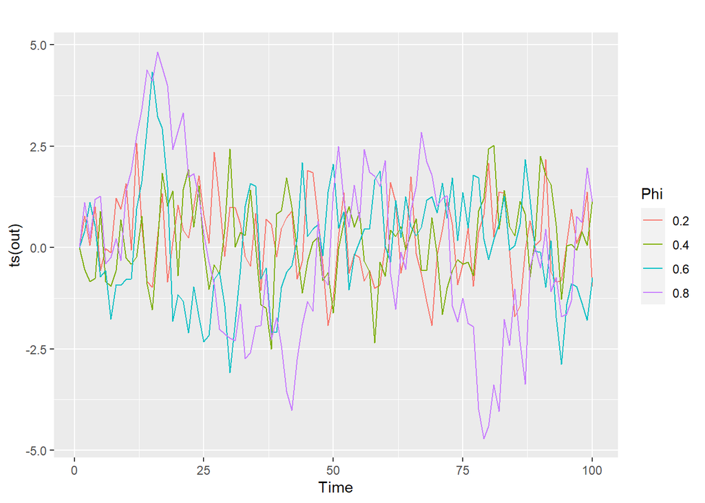

```r
my.arima <- function(p){
  y <- ts(numeric(100))
  e <- rnorm(100)
  for(i in 2:100){
    y[i] <- p*y[i-1] + e[i]
  }
  return(y)
}

#empty mat
out <- matrix(0, nrow = 100, ncol = 4)

#create some data for diff values of p
for(i in 1:4){
  out[1:100,i] <- my.arima(i*0.2)
}

#plot
colnames(out) <- c("0.2","0.4","0.6","0.8")
autoplot(ts(out)) +guides(colour = guide_legend(title = "Phi"))
```

### C) Write your own code to generate data from an MA(1) model with $\theta_1 = 0.6$ and $\sigma^2 = 1$

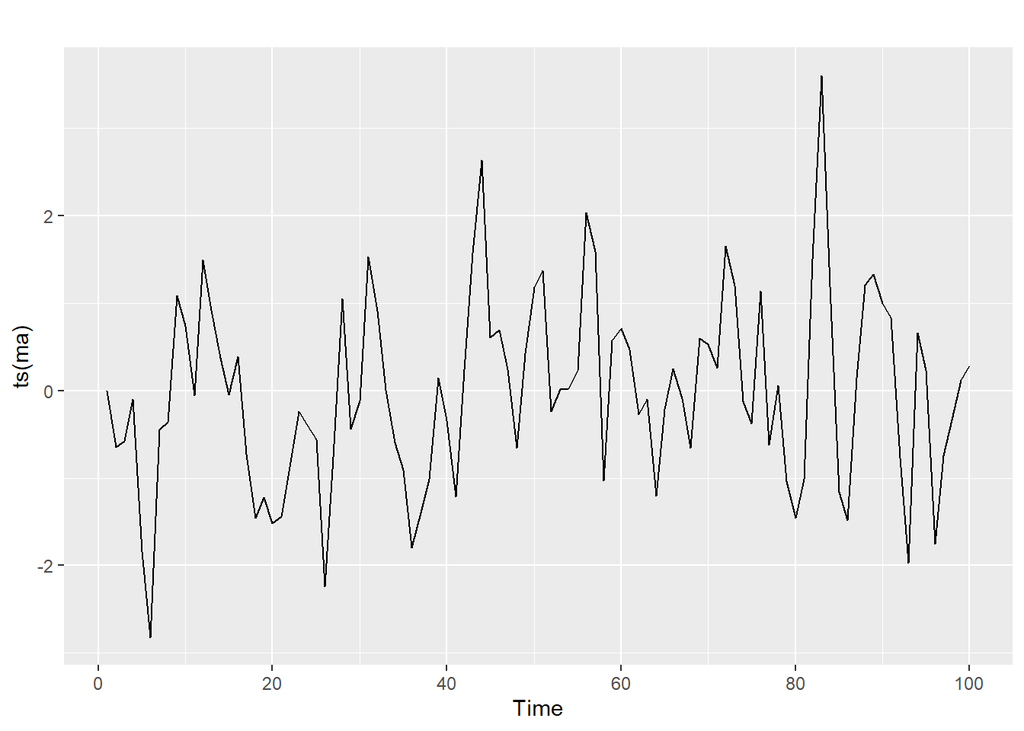

```r
my.ma <- function(t){
  y <- ts(numeric(100))
  e <- rnorm(100)
  for(i in 2:100){
    y[i] <- t*e[i-1] + e[i]
  }
  return(y)
}

ma <- my.ma(0.6)

autoplot(ts(ma))
```

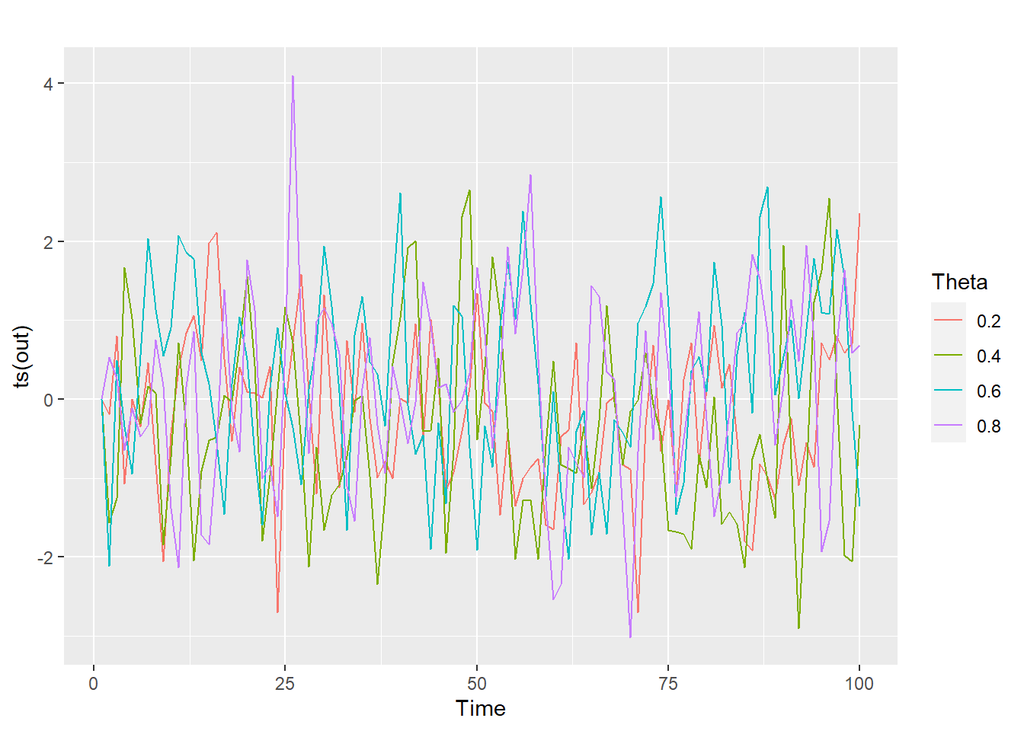

```r
#empty mat
out <- matrix(0, nrow = 100, ncol = 4)

#create some data for diff values of p
for(i in 1:4){
  out[1:100,i] <- my.ma(i*0.2)
}

#plot
colnames(out) <- c("0.2","0.4","0.6","0.8")
autoplot(ts(out)) +guides(colour = guide_legend(title = "Theta"))
```

### E) Generate data from an ARMA(1,1) model with $\phi_1 = 0.6$,$\theta_1 = 0.6$ and $\sigma^2 = 1$

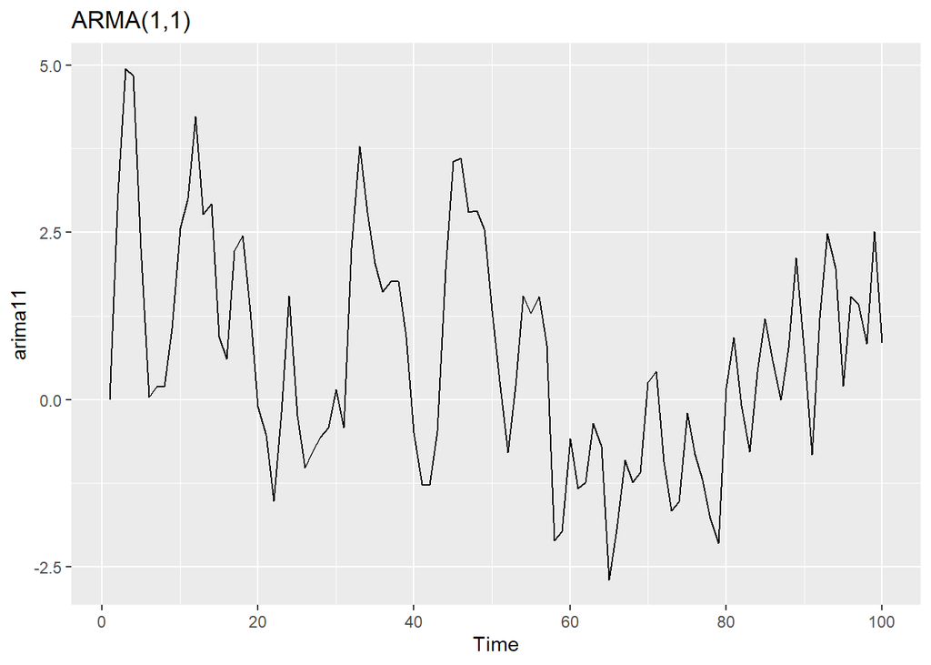

```r
y <- ts(numeric(100))
e <- rnorm(100)

for(i in 2:100)
  y[i] <- 0.6*y[i-1] + 0.6*e[i-1] + e[i]

arima11 <- y

autoplot(arima11) +
  ggtitle('ARMA(1,1)')
```

### F) Generate data from an AR(2) model with $\phi_1 = -0.8$, $\phi_2=0.3$ and $\sigma^2=1$.(Note that these parameters will give a non-stationary series.)

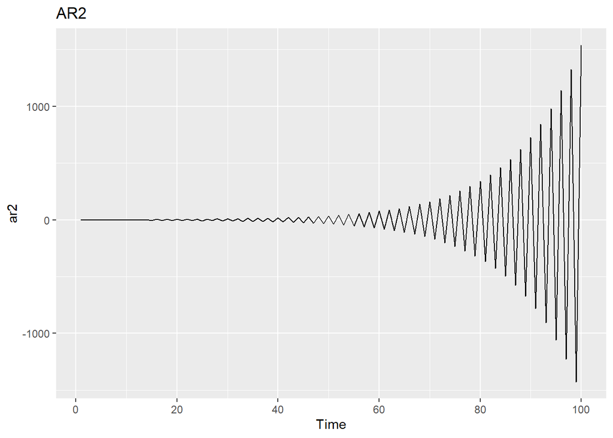

```r
y <- ts(numeric(100))
e <- rnorm(100)

for(i in 3:100)
  y[i] <- -0.8*y[i-1] + 0.3*y[i-2] + e[i]

ar2 <- y


autoplot(ar2) +
  ggtitle('AR2')
```

### G) Graph the latter two series and compare them.

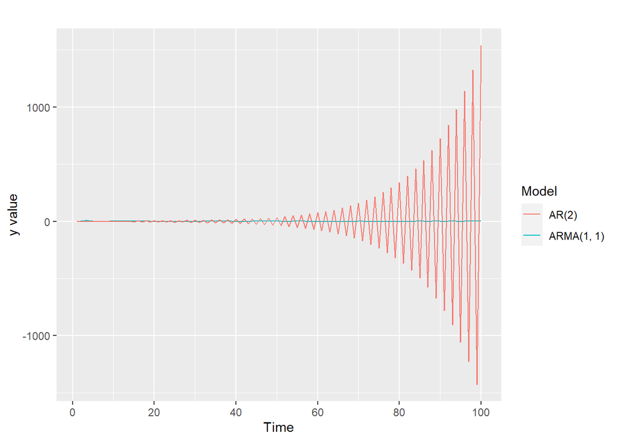

```r
autoplot(arima11, series = "ARMA(1, 1)") +
  autolayer(ar2, series = "AR(2)") +
  ylab("y value") +
  guides(colour = guide_legend(title = "Model"))
```

## Question 8.7

Consider wmurders, the number of women murdered each year (per 100,000 standard population) in the United States.

### A) By studying appropriate graphs of the series in R, find an appropriate ARIMA(p,d,q) model for these data

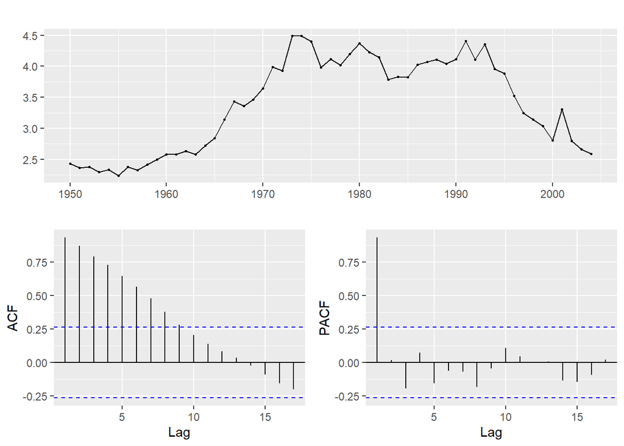

```r
d <- wmurders

ggtsdisplay(d)
```

The data is not stationary according to visual inspection. Observations: * The data exhibits piece-wise trending behaviour, flat, then up , then flat, then down. * The data exhibit a high degree of auto-correlation, especially at shorter lags. * The PCAF looks a bit better, but still shows a very value at the first lag. * There is no obvious seasonality or cyclicality in the data. * The variability seems reasonably constant (better seen below) and as such, no BoxCox is nessecary

Next we’ll look at the differenced data:

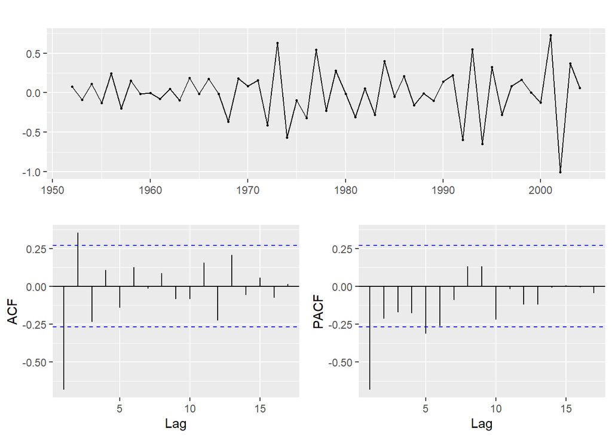

```r
n <- 2
ggtsdisplay(diff(d,difference=n))
```

```r
kpss.test(diff(d,difference=n))
```

```
##
##  KPSS Test for Level Stationarity
##
## data:  diff(d, difference = n)
## KPSS Level = 0.045793, Truncation lag parameter = 3, p-value = 0.1
```

We pass the KPSS test for stationarity using a 2nd order difference as above.

Based on the above, we can see that: *We have the appearance of a sinusoidal patter in the ACF* We see a large spike in PACF at lag=1 *We will use ARIMA(p,d,o) -> ARIMA(1,2,1)

### B) Should you include a constant in the model? Explain.

We have a model where d=2 so adding a constant will add a quadratic trend to the data. Given that the data represents the proportion of women murdered adding a constant seems inapproriate to me.

### C) Write this model in terms of the backshift operator.

In backshift operator terms, the model would be:

$(1-\phi_1B)(1-B)^2y_t = (1+\phi_1B)\varepsilon_t$ (ommiting the constant term)

### D) Fit the model using R and examine the residuals. Is the model satisfactory?

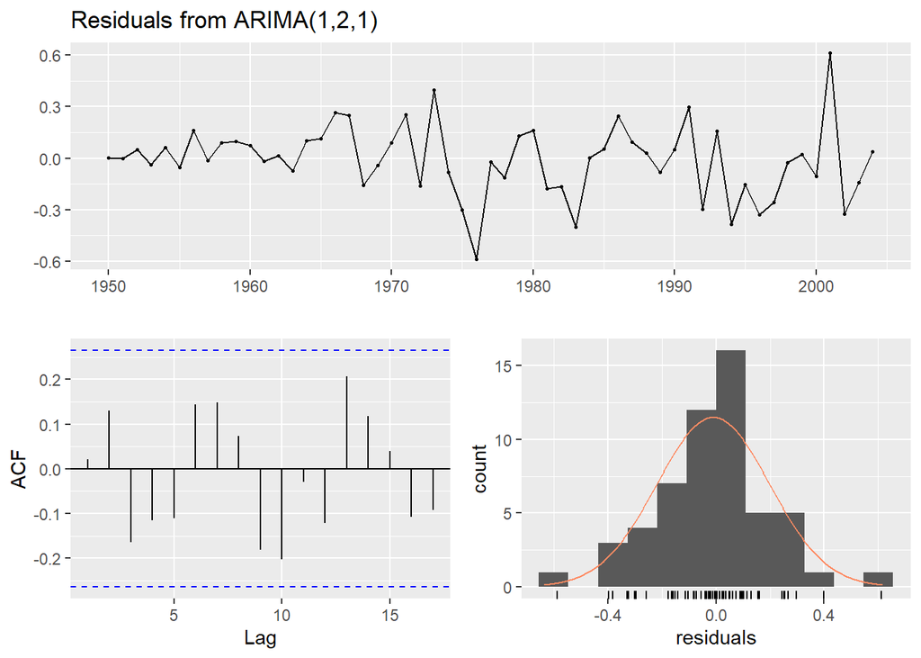

```
##
##  Ljung-Box test
##
## data:  Residuals from ARIMA(1,2,1)
## Q* = 12.419, df = 8, p-value = 0.1335
##
## Model df: 2.   Total lags used: 10
```

```r
my.arima <- Arima(wmurders, order=c(1,2,1))
checkresiduals(my.arima)
```

The model appears to be a decent fit based on the both the ACF plot and the distribution of residuals. The ACF values are all well within the critical values and the distribution of resituals is normal. This model is valid and acceptable.

### E) Forecast three times ahead. Check your forecasts by hand to make sure that you know how they have been calculated.

```r
f<- forecast(my.arima,h=3)
f
```

```
##      Point Forecast    Lo 80    Hi 80    Lo 95    Hi 95
## 2005       2.470660 2.194836 2.746484 2.048824 2.892496
## 2006       2.363106 1.986351 2.739862 1.786908 2.939304
## 2007       2.252833 1.765391 2.740276 1.507354 2.998313
```

Check:

```r
#req's inputs
recent <- tail(d,3)
residual <- tail(residuals(my.arima),1)

#model params
ar1 <- my.arima$coef[1]
ma1 <- my.arima$coef[2]

#compute each year manually
y1 <- 1.7566 * recent[3] - 0.5132  * recent[2] + ar1 * recent[1] + ma1 * residual
y2 <- 1.7566 * y1[1]- 0.5132  * recent[3] + ar1 * recent[2] + ma1 * 0
y3 <- 1.7566 * y2[1] - 0.5132  * y1[1] + ar1 * recent[3] + ma1 * 0

check <- data.frame(cbind(f$mean, c(y1,y2,y3)))
colnames(check) <- c("Model","Manual")

kable(check)
```

| Model | Manual |
| --- | --- |
| 2.470660 | 2.470527 |
| 2.363106 | 2.362740 |
| 2.252833 | 2.252133 |

The values are nearly identical with differences likely attributable to precision effects.

### F) Create a plot of the series with forecasts and prediction intervals for the next three periods shown.

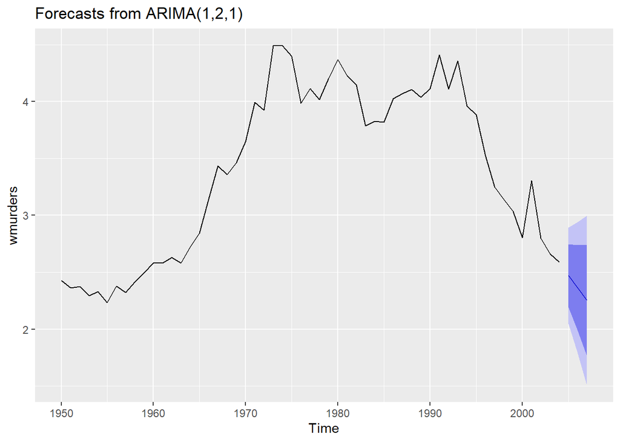

```r
autoplot(forecast(my.arima, h=3))
```

### G) Does auto.arima() give the same model you have chosen? If not, which model do you think is better?

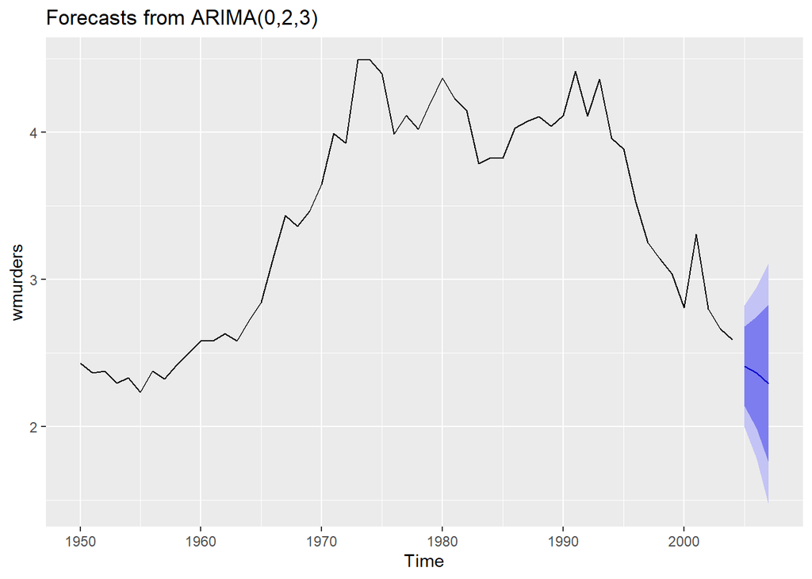

```r
not.my.arima <- auto.arima(wmurders, seasonal=F, stepwise=F, approximation=F)
autoplot(forecast(not.my.arima, h=3))
```